# Clean social navigation/replay data

# Setup

Loading in our usual libraries…

```r
library(tidyverse)
library(here)
```

```r
library(tidygraph)
library(ggraph)
```

If we convert the node labels into the right numeric IDs, we can capitalize upon materials created for other experiments in the lab, which have used the same underlying artificial network.

```r
node_crosswalk <- tribble(
  ~node_label, ~node_id,
  "B", 1,
  "L0", 2,
  "L1a", 3,
  "L1b", 4,
  "L2a", 5,
  "L2b", 6,
  "L3a", 7,
  "R0", 8,
  "R1a", 9,
  "R1b", 10,
  "R2a", 11,
  "R2b", 12,
  "R3a", 13
) %>% mutate(node_id = as.character(node_id))
```

# Load source data

Note: Despite what the variable names imply, these data are not the fully raw data, but come very close.

Some of the raw data inadvertently included information like IP addresses that could be considered sensitive and unsuitable for public sharing; the data in this repository have removed such information so that responses are fully anonymized. There were also a small number of subjects who had been noted as being noncompliant during the study session; their data were never analyzed, and additional subjects were recruited in their place to meet the target N. Those data are not included in the “source” datafiles here.

```r
raw_study1 <- here("data", "source_data", "social_navigation_study1.csv") %>%
  read_csv(show_col_types = FALSE)

raw_study2 <- here("data", "source_data", "social_navigation_study2.csv") %>%
  read_csv(show_col_types = FALSE)

# `readr::read_csv` throws a warning about parsing issues, and indeed the
# resulting tibble appears to contain problems...
#
# raw_study3 <- here("data", "source_data", "social_navigation_study3.csv") %>%
#   read_csv(show_col_types = FALSE)

raw_study3 <- here("data", "source_data", "social_navigation_study3.csv") %>%
  read.csv() %>%
  as_tibble()
```

# Stimulus mappings

Though every subject learned about the same network structure, stimuli were randomly mapped to nodes. Here, we’ll save the mappings from each subject’s session.

```r
clean_stim_mappings <- function(df) {
  df_of_names <- df %>%
    filter(!is.na(mapping_name)) %>%
    select(sub_id, mapping_name) %>%
    separate_longer_delim(mapping_name, ",") %>%
    group_by(sub_id) %>%
    mutate(node_name = lead(mapping_name)) %>%
    ungroup() %>%
    left_join(node_crosswalk, by = join_by(mapping_name == node_label)) %>%
    drop_na() %>%
    select(sub_id, node_id, node_name)

  df %>%
    filter(!is.na(mapping_img)) %>%
    select(sub_id, mapping_img) %>%
    mutate(
      mapping_img = str_remove_all(mapping_img, "img/"),
      # Raw column has the following structure:
      # node_A_id, node_A_stimfile, node_B_id, node_B_stimfile
      # Need to separate these out, but can't use commas as delim
      # Solution: use a little trick so that we can get unique delim
      mapping_img = str_replace_all(mapping_img, "\\.jpg,", "_"),
      mapping_img = str_remove(mapping_img, "\\.jpg")
    ) %>%
    separate_longer_delim(mapping_img, "_") %>%
    separate_wider_delim(
      mapping_img, ",", names = c("node_label", "node_stim")
    ) %>%
    left_join(node_crosswalk, by = join_by(node_label)) %>%
    mutate(
      node_race = str_sub(node_stim, 5, 5),
      node_gender = str_sub(node_stim, 6, 6),
      node_race = case_when(
        node_race == "A" ~ "asian",
        node_race == "B" ~ "black",
        node_race == "L" ~ "latine",
        node_race == "W" ~ "white"
      ),
      node_gender = if_else(node_gender == "F", "female", "male")
    ) %>%
    left_join(df_of_names, by = join_by(sub_id, node_id)) %>%
    select(sub_id, node_id, node_name, node_race, node_gender, node_stim) %>%
    mutate(node_id = as.numeric(node_id)) %>%
    arrange(sub_id, node_id)
}

nodes_study1 <- raw_study1 %>%
  clean_stim_mappings()

nodes_study2 <- raw_study2 %>%
  clean_stim_mappings()

nodes_study3 <- raw_study3 %>%
  clean_stim_mappings()
```

# Learning data

The cleaning procedure is exactly the same for all studies.

```r
clean_learning <- function(df) {
  df %>%
    # Keep relevant data only
    filter(trial_purpose == "memorygame_round") %>%
    select(
      sub_id, trial_index,
      target_id = pivot_id,
      target_friends = pivot_friends,
      guess_id = choice_seq
    ) %>%
    # Renumber trials
    group_by(sub_id) %>%
    mutate(trial = row_number()) %>%
    ungroup() %>%
    # On each trial, enumerate each guess made by the subject
    separate_rows(guess_id, sep = ",") %>%
    group_by(sub_id, trial) %>%
    mutate(guess_number = row_number()) %>%
    ungroup() %>%
    # Mark correct guesses
    mutate(guess_correct = str_detect(target_friends, guess_id)) %>%
    # Convert node labels into numeric IDs
    left_join(node_crosswalk, by = c("target_id" = "node_label")) %>%
    left_join(node_crosswalk, by = c("guess_id" = "node_label")) %>%
    type_convert(col_types = cols()) %>%
    # Make pretty
    arrange(sub_id, trial, guess_number) %>%
    select(
      sub_id, trial,
      target_id = node_id.x,
      guess_id = node_id.y,
      guess_number, guess_correct
    )
}

learn_study1 <- raw_study1 %>%
  clean_learning()

learn_study2 <- raw_study2 %>%
  clean_learning()

learn_study3 <- raw_study3 %>%
  clean_learning()
```

# Network data

All studies use exactly the same network. On day 2, both studies have a transition re-evaluation task where two network members are suddenly no longer friends, and two other network members suddenly become friends.

```r
nodelist <- learn_study1 %>%
  filter(guess_correct) %>%
  select(target_id, guess_id) %>%
  distinct() %>%
  pivot_longer(everything()) %>%
  select(node_id = value) %>%
  distinct() %>%
  arrange(node_id) %>%
  deframe()

edgelist <- learn_study1 %>%
  filter(guess_correct) %>%
  select(target_id, guess_id) %>%
  distinct() %>%
  rename(from = target_id, to = guess_id) %>%
  arrange(from, to)

adjlist <- expand_grid(from = nodelist, to = nodelist) %>%
  left_join(edgelist %>% mutate(edge = 1), by = c("from", "to")) %>%
  mutate(edge = if_else(is.na(edge), 0, edge))

adjlist_reevaluation <- adjlist %>%
  mutate(
    edge = case_when(
      # B and L0 no longer friends
      from == 1 & to == 2 ~ 0,
      from == 2 & to == 1 ~ 0,
      # R3a and L3a now friends
      from == 7 & to == 13 ~ 1,
      from == 13 & to == 7 ~ 1,
      TRUE ~ edge
    )
  )
```

We can first see what the original network looks like…

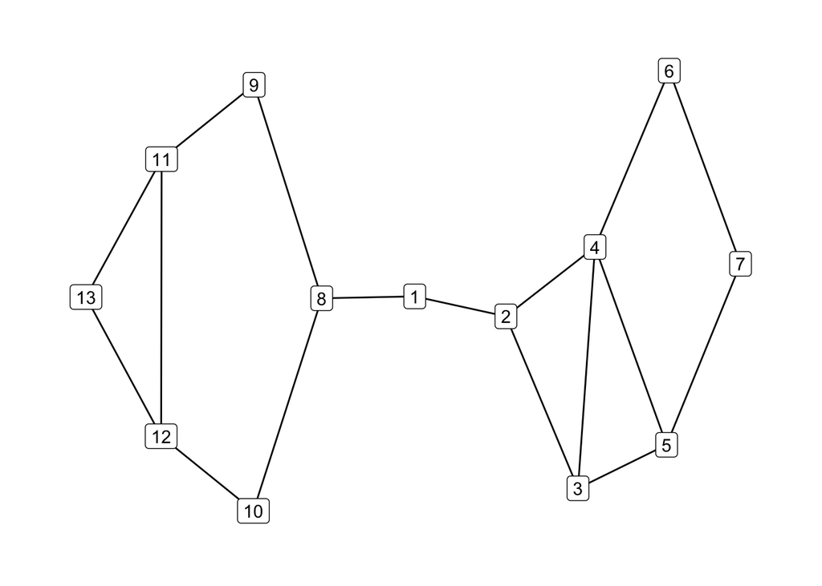

```r
adjlist %>%
  filter(edge == 1, from < to) %>%
  select(from, to) %>%
  tbl_graph(edges = ., directed = FALSE) %>%
  mutate(name = row_number()) %>%
  ggraph(layout = "stress") +
  theme_graph() +
  geom_edge_link() +
  geom_node_label(aes(label = name))
```

Then we’ll look at what happens once the friendships shift. The community structure remains largely the same, but node 1 is no longer the “broker” figure connecting them; instead, nodes 7 and 13 (who were formerly on the “fringe” of the network) become important brokers.

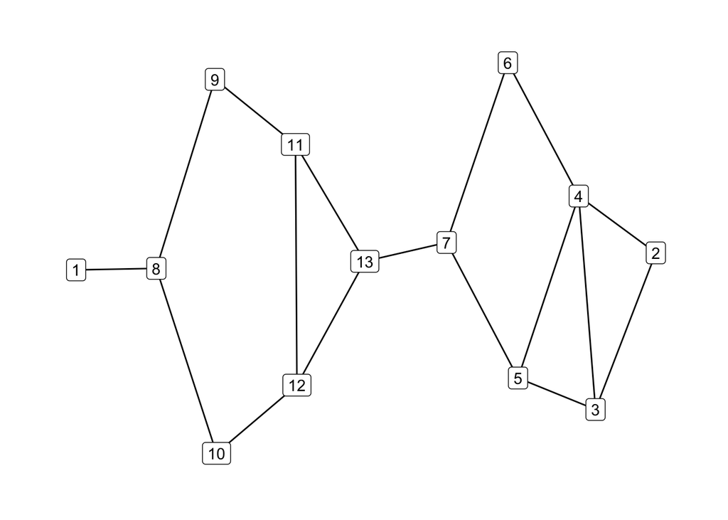

```r
adjlist_reevaluation %>%
  filter(edge == 1, from < to) %>%
  select(from, to) %>%
  tbl_graph(edges = ., directed = FALSE) %>%
  mutate(name = row_number()) %>%
  ggraph(layout = "stress") +
  theme_graph() +
  geom_edge_link() +
  geom_node_label(aes(label = name))
```

# Memory data

## Sequences of guesses

In the memory task, participants sequentially guessed which network members were friends with each other. Therefore, from the participants’ point of view, this task was functionally identical to the learning task, except all cards were face-up, and no feedback was provided.

```r
clean_memory_sequences <- function(df) {
  df %>%
    # Keep relevant data only
    filter(trial_purpose == "memory_quiz") %>%
    select(
      measurement_id, sub_id, trial_index,
      target_id = pivot_id,
      responses, rt
    ) %>%
    # Renumber trials
    group_by(sub_id, measurement_id) %>%
    mutate(trial = row_number()) %>%
    ungroup() %>%
    # Descend into regex hell
    mutate(
      guess_id = str_extract(responses, "\\[.+\\]"),
      guess_id = str_remove_all(guess_id, "\\[|\\]|\"")
    ) %>%
    # On each trial, enumerate each guess made by the subject
    separate_rows(guess_id, sep = ",") %>%
    group_by(sub_id, measurement_id, trial) %>%
    mutate(guess_number = row_number()) %>%
    ungroup() %>%
    # Convert node labels into numeric IDs
    left_join(node_crosswalk, by = c("target_id" = "node_label")) %>%
    left_join(node_crosswalk, by = c("guess_id" = "node_label")) %>%
    type_convert(col_types = cols()) %>%
    # Make pretty
    arrange(measurement_id, sub_id, trial, guess_number) %>%
    select(
      measurement_id, sub_id, trial,
      target_id = node_id.x,
      guess_id = node_id.y,
      guess_number
    ) %>%
    # Mark correct guesses
    left_join(adjlist, by = c("target_id" = "from", "guess_id" = "to")) %>%
    rename(guess_correct = edge)
}

mem_seq_study1 <- raw_study1 %>%
  mutate(measurement_id = 1) %>%
  clean_memory_sequences()

mem_seq_study2 <- raw_study2 %>%
  mutate(measurement_id = session) %>%
  clean_memory_sequences()

mem_seq_study3 <- raw_study3 %>%
  mutate(
    measurement_id = case_when(
      session == 1 & trial_index < 512 ~ 1,
      session == 1 ~ 2,
      session == 2 ~ 3,
    )
  ) %>%
  clean_memory_sequences()
```

## Traditional memory format

We can convert these sequences into a more “traditional” format for memory tasks. Basically, we can pretend that on each trial, participants were presented with a single pair of network members, and asked to indicate whether they were friends. Once in this format, it becomes really easy to convert responses into a matrix.

```r
clean_memory_traditional <- function(df) {
  expand_grid(
    df %>% select(measurement_id, sub_id) %>% distinct(),
    from = nodelist, to = nodelist
  ) %>%
    left_join(
      df %>%
        select(measurement_id, sub_id, from = target_id, to = guess_id) %>%
        mutate(choice = 1),
      by = c("measurement_id", "sub_id", "from", "to")
    ) %>%
    mutate(choice = if_else(is.na(choice), 0, choice)) %>%
    left_join(adjlist, by = c("from", "to")) %>%
    mutate(correct = choice == edge)
}

mem_all_study1 <- mem_seq_study1 %>%
  clean_memory_traditional()

mem_all_study2 <- mem_seq_study2 %>%
  clean_memory_traditional()

mem_all_study3 <- mem_seq_study3 %>%
  clean_memory_traditional()
```

# Message-passing task

In the message-passing task, participants learned that (e.g.) Abby wanted to send a message to Zoey. Given this goal, participants must decide whether to give the message to Farah or Sarah.

```r
clean_mpt <- function(df) {
  df %>%
    # Keep relevant data only
    filter(trial_purpose == "test_resp") %>%
    # Note from JYS:
    # The column `short_dist` is misleadingly named. Consider the set of trials
    # where startpoint==12 and endpoint==8. Node 12 can pass the message to any of
    # their friends: 10, 11, or 13. Let's call this 12-->8 set of trials a
    # testbed. For this testbed, the shortest possible distance, when considering
    # ALL of the options, is 2. This is the quantity encoded by `short_dist`.
    # Despite its name, it does NOT imply anything about the shortest path
    # distance GIVEN a set of options. For example, on the trial where subjects
    # must choose between options 11 and 13, the shortest distance GIVEN these
    # options is 3, NOT 2.
    select(
      measurement_id, sub_id, trial_index, network,
      rt, key_press, display_left,
      startpoint_id, endpoint_id,
      opt1_id, opt2_id,
      dist_opt1, dist_opt2,
      shortest_path_given_start_end = short_dist
    ) %>%
    mutate(
      # Did subjects choose option 1 or 2? Depends on whether "option 1" was
      # shown on the left or right side of the screen
      sub_choice = case_when(
        display_left == TRUE & key_press == 70 ~ opt1_id,
        display_left == FALSE & key_press == 74 ~ opt1_id,
        TRUE ~ opt2_id
      ),
      # The task sometimes presents subjects with an "impossible" option to
      # pass a message from one node to the endpoint without having the letter
      # return to the sender. The following code basically accounts for this
      # happening, when scoring the "correctness" of a subject's answer
      one_impossible_option = dist_opt1 == 0 | dist_opt2 == 0,
      # The task sometimes presents two equally correct answers
      two_correct_options = dist_opt1 == dist_opt2,
      shortest_path_given_opts = case_when(
        # Both distances are equal
        two_correct_options ~ dist_opt1,
        # Only one distance is "possible"
        one_impossible_option == TRUE & dist_opt1 > dist_opt2 ~ dist_opt1,
        one_impossible_option == TRUE & dist_opt1 < dist_opt2 ~ dist_opt2,
        # Otherwise, shortest distance is straightforward
        dist_opt1 < dist_opt2 ~ dist_opt1,
        dist_opt1 > dist_opt2 ~ dist_opt2
      ),
      correct_choice = case_when(
        # No single correct choice when both are equally good
        two_correct_options ~ NA_character_,
        # Penalize the impossible option
        one_impossible_option == TRUE & dist_opt1 > dist_opt2 ~ opt1_id,
        one_impossible_option == TRUE & dist_opt1 < dist_opt2 ~ opt2_id,
        # Otherwise, the correct answer is the shortest path
        dist_opt1 < dist_opt2 ~ opt1_id,
        dist_opt1 > dist_opt2 ~ opt2_id
      ),
      # Mark correct guesses based on the discrepancy between the subject's
      # choice vs what we know to be the "correct" choice
      correct = sub_choice == correct_choice | two_correct_options
    ) %>%
    # Relabel option IDs so that the correct answer is always first
    mutate(
      opt1_id_sorted = if_else(
        opt1_id == correct_choice | two_correct_options, opt1_id, opt2_id
      ),
      opt2_id_sorted = if_else(
        opt1_id == correct_choice | two_correct_options, opt2_id, opt1_id
      ),
      dist_opt1_sorted = if_else(
        opt1_id == correct_choice | two_correct_options, dist_opt1, dist_opt2
      ),
      dist_opt2_sorted = if_else(
        opt1_id == correct_choice | two_correct_options, dist_opt2, dist_opt1
      )
    ) %>%
    select(-c(opt1_id, opt2_id, dist_opt1, dist_opt2)) %>%
    rename(
      opt1_id = opt1_id_sorted,
      opt2_id = opt2_id_sorted,
      dist_opt1 = dist_opt1_sorted,
      dist_opt2 = dist_opt2_sorted
    ) %>%
    # Renumber trials
    group_by(measurement_id, sub_id, network) %>%
    mutate(trial = row_number()) %>%
    ungroup() %>%
    # Convert node labels into numeric IDs
    left_join(node_crosswalk, by = c("startpoint_id" = "node_label")) %>%
    left_join(node_crosswalk, by = c("endpoint_id" = "node_label")) %>%
    select(-c(startpoint_id, endpoint_id)) %>%
    rename(startpoint_id = node_id.x, endpoint_id = node_id.y) %>%
    left_join(node_crosswalk, by = c("opt1_id" = "node_label")) %>%
    left_join(node_crosswalk, by = c("opt2_id" = "node_label")) %>%
    select(-c(opt1_id, opt2_id)) %>%
    rename(opt1_id = node_id.x, opt2_id = node_id.y) %>%
    left_join(node_crosswalk, by = c("sub_choice" = "node_label")) %>%
    left_join(node_crosswalk, by = c("correct_choice" = "node_label")) %>%
    select(-c(sub_choice, correct_choice)) %>%
    rename(sub_choice = node_id.x, correct_choice = node_id.y) %>%
    type_convert(col_types = cols()) %>%
    # Mark "impossible" distances
    mutate(across(c(dist_opt1, dist_opt2), ~if_else(.x == 0, NA_real_, .x))) %>%
    # Make pretty
    arrange(measurement_id, sub_id, network, trial) %>%
    select(
      measurement_id, sub_id, network, trial,
      startpoint_id, endpoint_id, opt1_id, opt2_id,
      correct_choice, sub_choice, correct, rt,
      dist_opt1, dist_opt2,
      shortest_path_given_opts, shortest_path_given_start_end,
      one_impossible_option, two_correct_options
    ) %>%
    mutate(
      network = if_else(network == "main_network", "learned", "reevaluated")
    )
}

mpt_study1 <- raw_study1 %>%
  mutate(
    measurement_id = 1,
    network = "main_network"
  ) %>%
  clean_mpt()

mpt_study2 <- raw_study2 %>%
  mutate(measurement_id = session) %>%
  clean_mpt()

mpt_study3 <- raw_study3 %>%
  mutate(
    measurement_id = case_when(
      session == 1 & trial_index < 512 ~ 1,
      session == 1 ~ 2,
      session == 2 ~ 3,
    )
  ) %>%
  clean_mpt()
```

# Export data

```r
if (knitr::is_html_output()) {
  if (!dir.exists(here("data", "clean_data"))) {
    dir.create(here("data", "clean_data"))
  }

  ### Stim mappings
  nodes_study1 %>%
    write_csv(here("data", "clean_data", "study1_node_mappings.csv"))

  nodes_study2 %>%
    write_csv(here("data", "clean_data", "study2_node_mappings.csv"))

  nodes_study3 %>%
    write_csv(here("data", "clean_data", "study3_node_mappings.csv"))

  ### Learning
  learn_study1 %>%
    write_csv(here("data", "clean_data", "study1_learn.csv"))

  learn_study2 %>%
    write_csv(here("data", "clean_data", "study2_learn.csv"))

  learn_study3 %>%
    write_csv(here("data", "clean_data", "study3_learn.csv"))

  ### Memory sequences
  mem_seq_study1 %>%
    write_csv(here("data", "clean_data", "study1_memory_sequences.csv"))

  mem_seq_study2 %>%
    write_csv(here("data", "clean_data", "study2_memory_sequences.csv"))

  mem_seq_study3 %>%
    write_csv(here("data", "clean_data", "study3_memory_sequences.csv"))

  ### Memory pairwise
  mem_all_study1 %>%
    write_csv(here("data", "clean_data", "study1_memory.csv"))

  mem_all_study2 %>%
    write_csv(here("data", "clean_data", "study2_memory.csv"))

  mem_all_study3 %>%
    write_csv(here("data", "clean_data", "study3_memory.csv"))

  ### Message-passing task
  mpt_study1 %>%
    write_csv(here("data", "clean_data", "study1_message_passing.csv"))

  mpt_study2 %>%
    write_csv(here("data", "clean_data", "study2_message_passing.csv"))

  mpt_study3 %>%
    write_csv(here("data", "clean_data", "study3_message_passing.csv"))

  ### Network info
  adjlist %>%
    write_csv(here("data", "clean_data", "adjlist_learned.csv"))

  adjlist_reevaluation %>%
    write_csv(here("data", "clean_data", "adjlist_reevaluated.csv"))
}
```